# Prosper Loan Data Exploration

### Dataset Overview

The data set contains 113,937 records of loans along with 81 variables on each loan. After dropping some irrelevant features of our investigation, we have only 46 variables. The data set includes 31 float, 4 int, and 11 object variables.

### Investigation Overview

The main features we will investigate in this project are associated directly with answering the following questions:

- What factors affect users ability to get a loan?
- What factors impact a high prosper loan risk?
- What features affects the borrower’s APR or interest rate?
- Are there differences between loans depending on how large the original loan amount was?

These answers associated with many features but mainly 'CreditGrade', 'Term','BorrowerAPR', 'InterestRate', 'ProsperRatingAlpha', 'LoanStatus' and 'LoanOriginalAmount'.

## Univariate Exploration

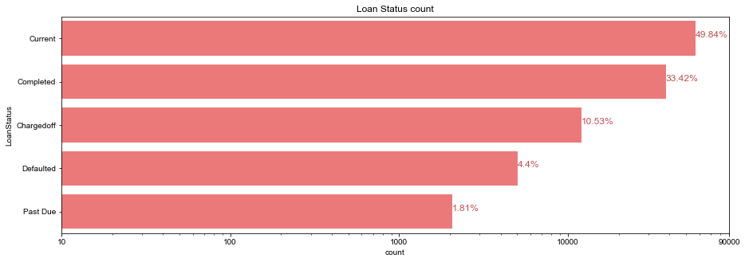

```python
# bar chart
plt.figure(figsize = [15, 5])
order = df['LoanStatus'].value_counts().index
plt.xscale('log')
plt.title('Loan Status count')
ax = sb.countplot(data = df, y = 'LoanStatus', color = '#ff6666', order=order)
sb.set()
x=[10, 100, 1000, 10000, 90000]
plt.xticks(x,x)

# Source https://robertmitchellv.com/blog-bar-chart-annotations-pandas-mpl.html
# https://matplotlib.org/api/text_api.html?highlight=get_text#matplotlib.text.Text
# list to collect plt.patches data
totals = []

# add values to the list
for i in ax.patches:
    totals.append(i.get_width())

total = sum(totals)

# loop to print the %
for i in ax.patches:
    ax.text(i.get_width()+.3, i.get_y()+0.38, \
            str(round((i.get_width()/total)*100, 2))+'%', fontsize=12,
color='r')
```

### Observation:

After the transformation of loan statues feature, the current loan statues ranked first with 49.84% while past due ranked last with only 1.81%. Prosper completed loan statues were equal to 33.42% which represented a positive users commitment.

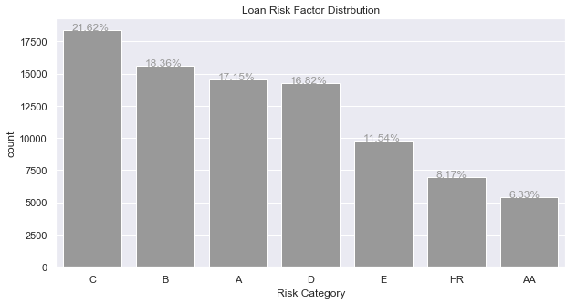

```python
plt.figure(figsize = [10, 5])
plt.title('Loan Risk Factor Distrbution')
order = df['ProsperRatingAlpha'].value_counts().index
ax = sb.countplot(data = df, x = 'ProsperRatingAlpha', order=order, color='#999999')
plt.xlabel('Risk Category')
sb.set();

# representing %
totals = []

for i in ax.patches:
    totals.append(i.get_height())

total = sum(totals)

for i in ax.patches:
    ax.text(i.get_x()+.12, i.get_height()-3, \
            str(round((i.get_height()/total)*100, 2))+'%', fontsize=12,
                color='#999999')
```

### Observation:

The bar graph above demonstrates the prosper risk factor distribution. The graph shows 21.62% of loans were under C risk category, 18.36% under B and 17.15% under A. All the higher ranked categories A, B & C has risk from 9-18% based on prosper predefined rules which considered as a reasonable risk, not a higher risk.

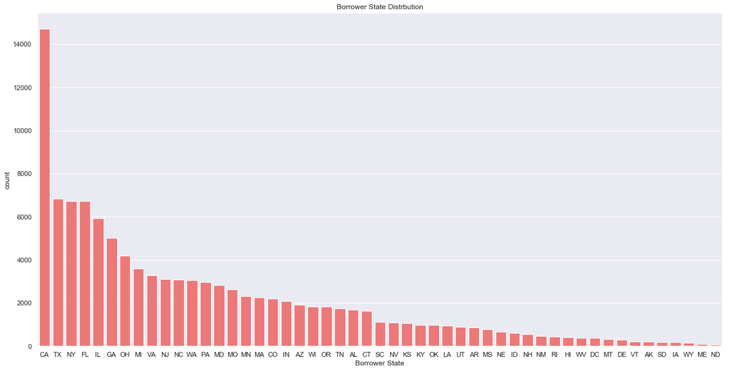

```python
plt.figure(figsize = [20, 10])
plt.title('Borrower State Distrbution')
order = df['BorrowerState'].value_counts().index
sb.countplot(data = df, x = 'BorrowerState', order=order, color='#ff6666')
plt.xlabel('Borrower State')
sb.set();
```

### Observation:

The graph shows that CA is the top state of borrowing prosper loans among all the state followed by TX, NY, and FL with a slight difference among them. On the other hand, IA, WY, ME and ND were the least state in borrowing prosper loans.

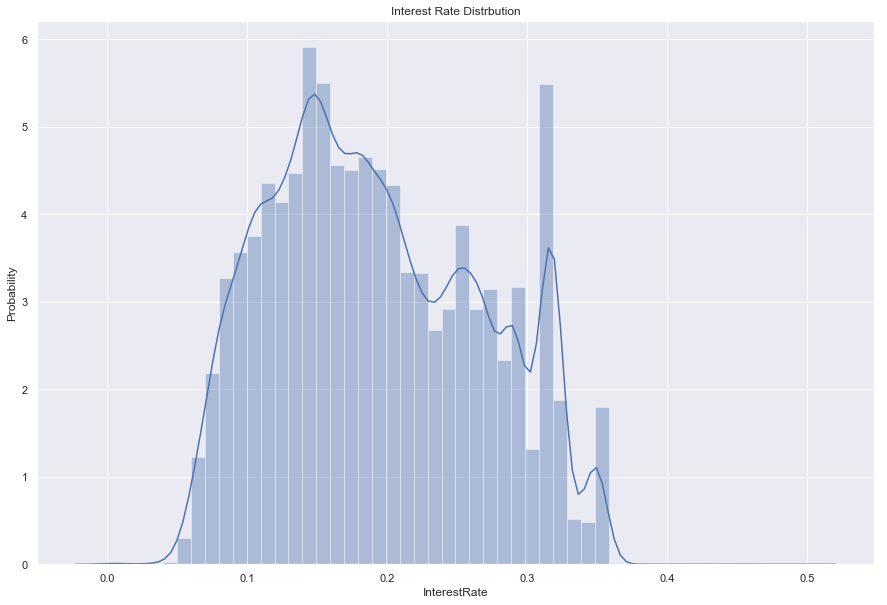

```python
plt.figure(figsize=[15, 10])
sb.distplot(df['InterestRate'])
plt.title('Interest Rate Distrbution')
plt.ylabel('Probability')
sb.set();
```

### Observation:

The interest rate distribution seems bimodal, since it has two peaks. Also, a major lack of fit exists on the right side of the observed distribution where the second peak appears. Thus to conclude from the analysis, the continuous normal distribution probably does not provide adequate information for the observed distribution.

## Bivariate Exploration

#### ProsperRatingAlpha vs LoanStatus

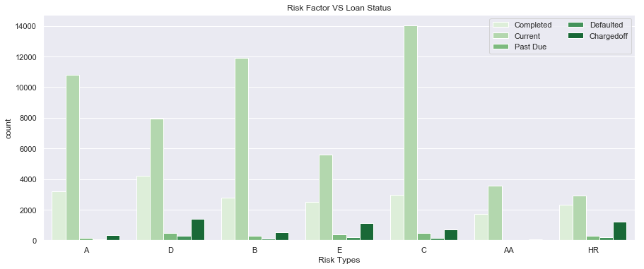

```python
plt.figure(figsize = [15, 20])
ax = plt.subplot(3, 1, 3)
sb.countplot(data = df, x = 'ProsperRatingAlpha', hue = 'LoanStatus', palette = 'Greens')
ax.legend(loc = 1, ncol = 2) # re-arrange legend to remove overlapping
plt.title('Risk Factor VS Loan Status')
plt.xlabel('Risk Types')
plt.show()
```

### Observation:

I was interested to compare the risk level with the loan status. As expacted, most of the current loans were under C, B, and A respectively moderate risk levels while most completed loans fill under D risk category. The graph also indicates that a little amount of current and completed loans were under AA (lower risk) risk category only. This an interesting relationship as almost a significant amount of prosper's loan borrowers tend to take moderate to higher level category risk.

#### CreditGrade vs LoanOriginalAmount

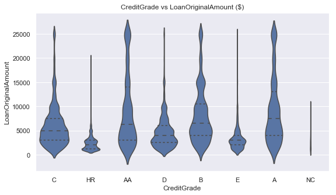

```python
plt.figure(figsize = [9, 5])
plt.title('CreditGrade vs LoanOriginalAmount ($)')
base_color = sb.color_palette()[0]
# use count scale to get grasp into the distribution
sb.violinplot(data = df, x = 'CreditGrade', y = 'LoanOriginalAmount', color = base_color,
              inner = 'quartile', scale='count');
```

### Observation:

A very interesting relation represented using the above violin plot. The graph shows the distribution shape of all credit grade compared to loan original amount. Almost credit grade AA, A, B, C, and D had the largest values and reasonable distribution shape. According to the loan original amount values, the median of credit grade A was the largest followed by B then AA respectively. This correlation indicates that as credit grade get higher as the original amount of loans increases.

#### Term vs InterestRate

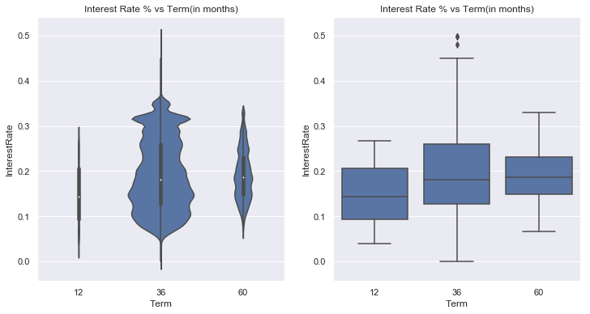

```python
plt.figure(figsize = [12, 6])
base_color = sb.color_palette()[0]

# violin plot
plt.subplot(1, 2, 1)
ax1 = sb.violinplot(data = df, x = 'Term', y = 'InterestRate', color = base_color, scale='count')
plt.title('Interest Rate % vs Term(in months)')

# box plot
plt.subplot(1, 2, 2)
sb.boxplot(data = df, x = 'Term', y = 'InterestRate', color = base_color)

plt.title('Interest Rate % vs Term(in months)')
plt.ylim(ax1.get_ylim());
```

### Observation:

The box plot above shows that the higher median of interest rate was represented in the 5 years term loans which approximately reach a 0.19. Also, the lowest median was associated with one-year term loans as expected. The violin graph shows the distribution more clearly, which indicate most contributed loans were 3 years term period with a median of interest rate equal to 0.17 approximately. As represented, loans taken by one year period have less interest rates than the longer term loans.

#### InterestRate vs CreditGrade

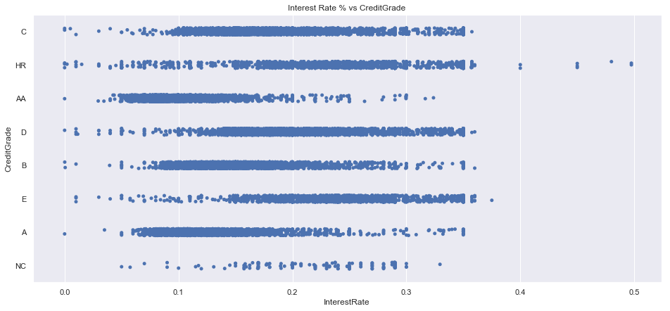

```python
plt.figure(figsize = [16, 7])
base_color = sb.color_palette()[0]

# strip plot
ax1 = sb.stripplot(data = df, x = 'InterestRate', y = 'CreditGrade',
                   color = base_color)

plt.title('Interest Rate % vs CreditGrade');
```

### Observation:

As expected as the credit grade increases as the interest rate decrease. A strong correlation indicated in the above graph.

## Multivariate Exploration

#### LoanOriginalAmount vs MonthlyLoanPayment vs Term

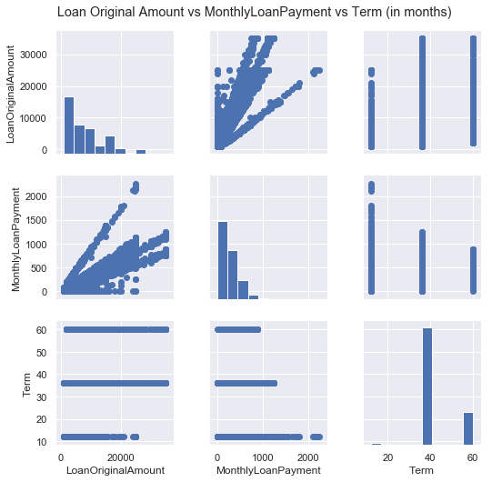

```python
g = sb.PairGrid(data = df, vars = ['LoanOriginalAmount', 'MonthlyLoanPayment', 'Term'])
g.map_diag(plt.hist)
g.map_offdiag(plt.scatter)
g.fig.subplots_adjust(top=0.93, wspace=0.3)
g.fig.suptitle('Loan Original Amount vs MonthlyLoanPayment vs Term (in months)');
```

### Observation:

The pair grid above used to investigate the relation between LoanOriginalAmount, MonthlyLoanPayment and Term more. One indication from the read of the above graph that almost all the one year borrowers tend to pay there monthly amount comparing with the other terms. Also, as the higher number of users tend to have three years period term they don't show commitment to pay their monthly portion. To resolve this issue, the borrowers who struggle with their monthly payment rate should extend the term from 3 years to 5 years and borrow a lesser amount of loan.

#### BorrowerAPR vs InterestRate vs ProsperRatingNumeric

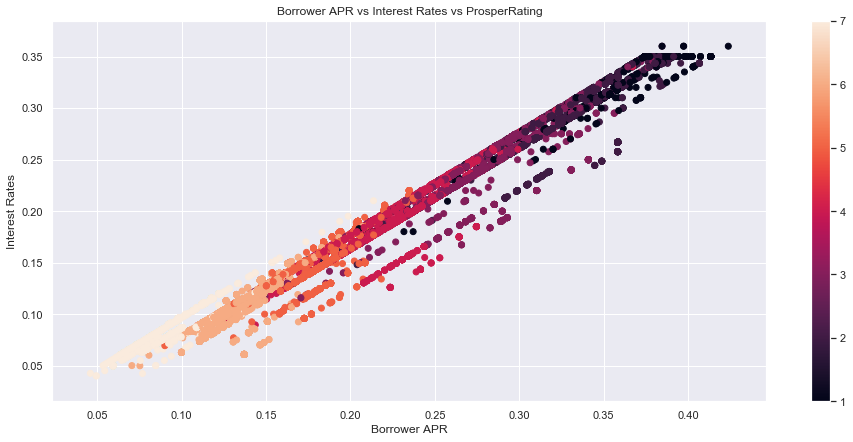

```python
plt.figure(figsize = [16, 7])
plt.scatter(data = df, x = 'BorrowerAPR', y = 'InterestRate', c = 'ProsperRatingNumeric')
plt.colorbar()
plt.xlabel('Borrower APR')
plt.ylabel('Interest Rates')
plt.title('Borrower APR vs Interest Rates vs ProsperRating');
```

### Observation:

The scatter plot above shows a strong correlation between APR, interest rate and prosper rating of the risk. As the prosper rating gets higher as both APR & interest rate get lower.

#### LoanOriginationQuarter vs InterestRate vs Term

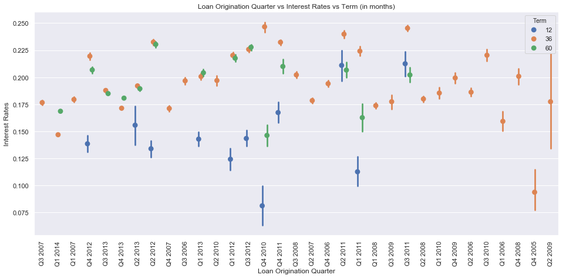

```python
plt.figure(figsize = [16, 7])
ax = sb.pointplot(data = df, x = 'LoanOriginationQuarter', y = 'InterestRate', hue = 'Term',
                  dodge = 0.3, linestyles = "")
plt.xlabel('Loan Origination Quarter')
plt.ylabel('Interest Rates')
plt.title('Loan Origination Quarter vs Interest Rates vs Term (in months)')
plt.xticks(rotation = 90);
```